# Human Resources Analytics - Employee Churn Predication Analysis

## 3b. Correlation Matrix & Heatmap

**Moderate Positively Correlated Features:**

- projectCount vs evaluation: 0.589298
- projectCount vs averageMonthlyHours: 0.672565
- averageMonthlyHours vs evaluation: 0.576610

**Moderate Negatively Correlated Feature:**

- satisfaction vs turnover: -0.339162

**Stop and Think:**

- What features affect our target variable the most (turnover)?
- What features have strong correlations with each other?
- Can we do a more in depth examination of these features?

**Summary:**

From the heatmap, there is a **positive(+)** correlation between projectCount, averageMonthlyHours, and evaluation. Which could mean that the employees who spent more hours and did more projects were evaluated highly.

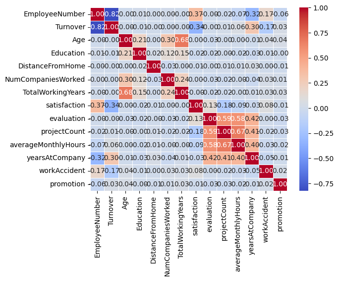

|  | EmployeeNumber | Turnover | Age | Education | DistanceFromHome | NumCompaniesWorked | TotalWorkingYears | satisfaction | evaluation | projectCount | averageMonthlyHours | yearsAtCompany | workAccident | promotion |
| --- | --- | --- | --- | --- | --- | --- | --- | --- | --- | --- | --- | --- | --- | --- |
| EmployeeNumber | 1.000000 | -0.823362 | -0.004801 | 0.006923 | 0.001119 | 0.004336 | -0.003170 | 0.365636 | -0.004017 | -0.015902 | -0.071626 | -0.316703 | 0.169671 | -0.055833 |
| Turnover | -0.823362 | 1.000000 | -0.001956 | -0.008479 | -0.000469 | 0.001325 | -0.003494 | -0.339162 | -0.002154 | 0.013037 | 0.055978 | 0.297399 | -0.169064 | 0.034250 |
| Age | -0.004801 | -0.001956 | 1.000000 | 0.207696 | 0.002168 | 0.297806 | 0.680348 | 0.002470 | -0.025124 | -0.001757 | 0.000639 | -0.007051 | 0.038006 | 0.035821 |
| Education | 0.006923 | -0.008479 | 0.207696 | 1.000000 | 0.018115 | 0.124597 | 0.151809 | -0.022216 | -0.024156 | -0.002606 | -0.021667 | -0.029629 | -0.008681 | -0.001495 |
| DistanceFromHome | 0.001119 | -0.000469 | 0.002168 | 0.018115 | 1.000000 | -0.029003 | 0.002636 | -0.006993 | -0.003108 | 0.008635 | 0.009611 | 0.034274 | 0.000805 | -0.005903 |
| NumCompaniesWorked | 0.004336 | 0.001325 | 0.297806 | 0.124597 | -0.029003 | 1.000000 | 0.235825 | 0.001758 | -0.025257 | -0.019258 | -0.002271 | -0.037710 | 0.029808 | 0.010397 |
| TotalWorkingYears | -0.003170 | -0.003494 | 0.680348 | 0.151809 | 0.002636 | 0.235825 | 1.000000 | -0.004955 | -0.021076 | -0.017836 | -0.003970 | 0.005211 | 0.027910 | 0.031594 |
| satisfaction | 0.365636 | -0.339162 | 0.002470 | -0.022216 | -0.006993 | 0.001758 | -0.004955 | 1.000000 | 0.127214 | -0.181059 | -0.087267 | -0.031065 | 0.075399 | -0.008571 |
| evaluation | -0.004017 | -0.002154 | -0.025124 | -0.024156 | -0.003108 | -0.025257 | -0.021076 | 0.127214 | 1.000000 | 0.589298 | 0.576610 | 0.421267 | 0.002264 | -0.027389 |
| projectCount | -0.015902 | 0.013037 | -0.001757 | -0.002606 | 0.008635 | -0.019258 | -0.017836 | -0.181059 | 0.589298 | 1.000000 | 0.672565 | 0.406069 | -0.015214 | -0.026561 |
| averageMonthlyHours | -0.071626 | 0.055978 | 0.000639 | -0.021667 | 0.009611 | -0.002271 | -0.003970 | -0.087267 | 0.576610 | 0.672565 | 1.000000 | 0.400113 | -0.029533 | -0.021271 |
| yearsAtCompany | -0.316703 | 0.297399 | -0.007051 | -0.029629 | 0.034274 | -0.037710 | 0.005211 | -0.031065 | 0.421267 | 0.406069 | 0.400113 | 1.000000 | -0.049543 | -0.006864 |
| workAccident | 0.169671 | -0.169064 | 0.038006 | -0.008681 | 0.000805 | 0.029808 | 0.027910 | 0.075399 | 0.002264 | -0.015214 | -0.029533 | -0.049543 | 1.000000 | 0.022185 |
| promotion | -0.055833 | 0.034250 | 0.035821 | -0.001495 | -0.005903 | 0.010397 | 0.031594 | -0.008571 | -0.027389 | -0.026561 | -0.021271 | -0.006864 | 0.022185 | 1.000000 |

```python
# Filter only numeric columns for correlation matrix
numeric_columns = df.select_dtypes(include=['number']).columns

# Compute the correlation matrix for numeric columns only
corr = df[numeric_columns].corr()

# Plotting the heatmap
import seaborn as sns
import matplotlib.pyplot as plt

sns.heatmap(corr,
            xticklabels=corr.columns.values,
            yticklabels=corr.columns.values,
            cmap='coolwarm',  # Color map for better visualization
            annot=True,       # Annotate the heatmap with correlation values
            fmt='.2f',        # Formatting the numbers to 2 decimal places
            linewidths=0.5)   # Adding linewidths for separation of cells

# Display the plot
plt.show()

# Display the correlation matrix
corr
```

**Summary of the Heatmap** The heatmap visually represents the correlation matrix derived from the data. The color scale ranges from blue (negative correlation) to red (positive correlation). The numerical values within each cell represent the correlation coefficients ranging between -1 (perfect negative correlation) and +1 (perfect positive correlation).

**Key Observations from the Correlation Matrix**

A. **Strong Correlations:**

1. **Evaluation and ProjectCount:** A high positive correlation of 0.589. Employees with higher evaluation scores tend to handle more projects.
2. **Evaluation and averageMonthlyHours:** Correlation of 0.577. Higher evaluation is associated with longer working hours.
3. **ProjectCount and averageMonthlyHours:** Correlation of 0.673. Employees with a higher project count tend to work longer hours.

B. **Weak/No Significant Correlations:**

1. Variables like Education, DistanceFromHome, and Promotion exhibit weak or negligible correlations with other variables, including turnover.
2. WorkAccident shows very low correlation with most variables, indicating accidents are not significantly related to factors like satisfaction, evaluation, or project count.

C. **Turnover (Turnover Column):**

1. Turnover is negatively correlated with Satisfaction (-0.339), indicating that lower satisfaction is associated with higher turnover.
2. Positive correlation with yearsAtCompany (0.297) suggests that employees with a longer tenure at the company are slightly more likely to leave.
3. Turnover has a negligible correlation with factors like Age, Education, and DistanceFromHome, implying these variables may not play a significant role in explaining turnover.

**Key Insights from Satisfaction and Evaluation:**

1. **Satisfaction and Turnover:** Negative correlation indicates dissatisfied employees are more likely to leave.
2. **Evaluation and Turnover:** Negligible correlation suggests performance evaluations alone are not major determinants of turnover.

**Interpretation of Results**

1. **Business Implications for Turnover:**
   - Focus on employee satisfaction as it is a critical factor influencing turnover. Addressing dissatisfaction could lead to retention.
   - Reassess long-tenured employees’ needs as turnover increases with tenure, potentially indicating stagnation or lack of growth opportunities.
2. **Workload and Performance:**
   - Higher evaluation scores correlate with more projects and working hours, indicating that top performers may be overburdened. This could lead to burnout or turnover in the long term.
3. **Promotion and Work Accident:**
   - Weak correlations with turnover suggest these are not primary drivers. However, ensuring fair promotion opportunities and workplace safety remains essential.
4. **Education and Age:**
   - Minimal impact on turnover indicates that these factors may not require targeted intervention for employee retention.

**Conclusion** The heatmap and correlation matrix provide valuable insights into relationships between variables. To reduce turnover, organizations should prioritize increasing employee satisfaction and consider workload distribution for high-performing employees.

## 3b2. Statistical Test for Correlation

### One-Sample T-Test (Measuring Satisfaction Level)

A one-sample t-test checks whether a sample mean differs from the population mean. Since satisfaction has the highest correlation with our dependent variable turnover, let's test to see whether the average satisfaction level of employees that had a turnover differs from the those that had no turnover.

**Hypothesis Testing:** Is there significant difference in the **means of satisfaction level** between employees who had a turnover and employees who had no turnover?

- **Null Hypothesis:** *(H0: pTS = pES)* there is **no** difference in satisfaction level between employees who did turnover and those who did not..
- **Alternate Hypothesis:** *(HA: pTS != pES)* there **is** a difference in satisfaction level between employees who did turnover and those who did not..

```python
# Let's compare the means of our employee turnover satisfaction against the employee population satisfaction
#emp_population = df['satisfaction'].mean()
emp_population = df['satisfaction'][df['Turnover'] == 0].mean()
emp_turnover_satisfaction = df[df['Turnover']==1]['satisfaction'].mean()

print( 'The mean satisfaction for the employee population with no turnover is: ' + str(emp_population))
print( 'The mean satisfaction for employees that had a turnover is: ' + str(emp_turnover_satisfaction) )
```

```
The mean satisfaction for the employee population with no turnover is: 0.667061191626409
The mean satisfaction for employees that had a turnover is: 0.4751441899915182
```

**Detailed Summary of Results**

1. **Satisfaction Levels:**
   - Employees with no turnover:** Average satisfaction is significantly higher (~0.667).
   - Employees with turnover:** Average satisfaction is considerably lower (~0.475).
2. **Insight:** -Employees who left the company had much lower satisfaction levels compared to those who stayed. -This suggests that job satisfaction is a critical factor in employee retention.
3. **Potential Business Implications:** **-Retention Strategy:** Focus on improving overall employee satisfaction to reduce turnover rates. **-Targeted Interventions:** Identify employees with declining satisfaction and provide support or address grievances to prevent them from leaving. **-Employee Surveys:** Regularly measure satisfaction to proactively monitor employee sentiment.

**Conclusion** The significant difference in satisfaction levels between employees with and without turnover highlights the importance of employee satisfaction as a predictor of retention. Organizations should prioritize strategies that enhance job satisfaction, such as:

- Improving work-life balance.
- Offering professional growth opportunities.
- Acknowledging and rewarding performance.

### Conducting the T-Test

Let's conduct a t-test at **95% confidence level** and see if it correctly rejects the null hypothesis that the sample comes from the same distribution as the employee population. To conduct a one sample t-test, we can use the **stats.ttest_1samp()** function:

```python
import scipy.stats as stats
stats.ttest_1samp(a=  df[df['Turnover']==1]['satisfaction'], # Sample of Employee satisfaction who had a Turnover
                  popmean = emp_population)  # Employee Who Had No Turnover satisfaction mean
```

```
TtestResult(statistic=-34.288927883681865, pvalue=2.1466974885447805e-209, df=2357)
```

**Objective** The goal of the T-Test is to determine if there is a statistically significant difference between the satisfaction levels of employees who left the company (Turnover = 1) and the average satisfaction level of employees who stayed (Turnover = 0).

This is a one-sample t-test, where the null hypothesis:- Null Hypothesis: (H0: pTS = pES) There is no difference in satisfaction level between employees who did turnover and those who did not.. If the null hypothesis is rejected, it indicates that the satisfaction levels of employees who left are significantly different from those who stayed.

**Result Interpretation**

**T-Statistic:** 1. Value: -34.29 2. A large negative value indicates that the sample mean (satisfaction of employees who left) is significantly lower than the population mean (satisfaction of employees who stayed).

**P-Value:** 1. Value: 2.1466974885447805e-209. 2. The p-value represents the probability of observing the data if the null hypothesis is true. Since the p-value is extremely small (essentially 0) and well below the commonly used significance threshold of 0.05, the null hypothesis is strongly rejected.

**Conclusion**

1. **Rejecting the Null Hypothesis:**
   - The mean satisfaction of employees who left the company is significantly lower than the mean satisfaction of employees who stayed.
   - This supports the hypothesis that low satisfaction levels are strongly associated with employee turnover.
2. **Practical Implication:**
   - This finding reinforces the importance of monitoring and addressing employee satisfaction to reduce turnover.
   - Organizations should consider implementing strategies such as better engagement, recognition, and support systems to improve overall satisfaction and retention.
3. **Significance:**
   - The extremely low p-value highlights the robustness of this finding and eliminates any doubt about the result being due to random chance.

**Final Summary** The T-Test conclusively shows a statistically significant difference in satisfaction levels between employees who left and those who stayed. The low satisfaction levels of employees who left should prompt businesses to take immediate corrective actions to prevent further turnover.

### T-Test Result

The test result shows the **test statistic "t" is equal to -34.29**. This test statistic tells us how much the sample mean deviates from the null hypothesis. If the t-statistic lies **outside** the quantiles of the t-distribution corresponding to our confidence level and degrees of freedom, we reject the null hypothesis. We can check the quantiles with **stats.t.ppf()**:

### T-Test Quantile

If the t-statistic value we calculated above **(-34.29)** is outside the quantiles, then we can reject the null hypothesis

```python
degree_freedom = len(df[df['Turnover']==1])

LQ = stats.t.ppf(0.025,degree_freedom)  # Left Quartile

RQ = stats.t.ppf(0.975,degree_freedom)  # Right Quartile

print ('The t-distribution left quartile range is: ' + str(LQ))
print ('The t-distribution right quartile range is: ' + str(RQ))
```

```
The t-distribution left quartile range is: -1.9609705446242267
The t-distribution right quartile range is: 1.9609705446242263
```

**Objective** -If the calculated t-statistic falls outside this range, we reject the null hypothesis.

**Result Interpretation**

1. **Left Quartile (LQ):**
   - LQ=−1.9609705446242267
   - This is the lower critical boundary. Any t-statistic below this value falls into the rejection region.
2. **Right Quartile (RQ):**
   - RQ=1.9609705446242263
   - This is the upper critical boundary. Any t-statistic above this value falls into the rejection region.
3. **t-Statistic Comparison:**
   - Calculated t-statistic: -34.29
   - Since -34.29 is far below the lower critical value (−1.96), it falls into the rejection region.

**Conclusion**

1. **Null Hypothesis Rejected:**
   - The calculated t-statistic (−34.29) is far outside the critical range ([−1.96,1.96]).
   - This provides additional evidence that the satisfaction levels of employees who left are significantly different from those who stayed.
2. **Significance of Quantiles:**
   - The critical quantiles define the confidence interval where we would fail to reject the null hypothesis.
   - Any t-statistic outside this range strongly supports rejecting 𝐻0.

**Practical Implication** The quantile analysis confirms that the satisfaction levels of employees who left are not drawn from the same distribution as those who stayed. This further validates the earlier findings of the t-test and emphasizes the need for addressing dissatisfaction to reduce turnover.

**Summary** The t-distribution quantile test strengthens the conclusion that the difference in satisfaction levels between employees who left and stayed is statistically significant. The t-statistic is well outside the confidence range, leaving no doubt that low satisfaction correlates with turnover.

## 3c. Distribution Plots (Satisfaction - Evaluation - AverageMonthlyHours)

**Summary:** Let's examine the distribution on some of the employee's features:

- **Satisfaction** - There is a huge spike for employees with low satisfaction and high satisfaction.
- **Evaluation** - There is a bimodal distrubtion of employees for low evaluations (less than 0.6) and high evaluations (more than 0.8)
- **AverageMonthlyHours** - There is another bimodal distribution of employees with lower and higher average monthly hours (less than 150 hours & more than 250 hours)
- The evaluation and average monthly hour graphs both share a similar distribution.
- Employees with lower average monthly hours were evaluated less and vice versa.
- If you look back at the correlation matrix, the high correlation between evaluation and averageMonthlyHours does support this finding.

**Stop and Think:**

- Is there a reason for the high spike in low satisfaction of employees?
- Could employees be grouped in a way with these features?
- Is there a correlation between evaluation and averageMonthlyHours?

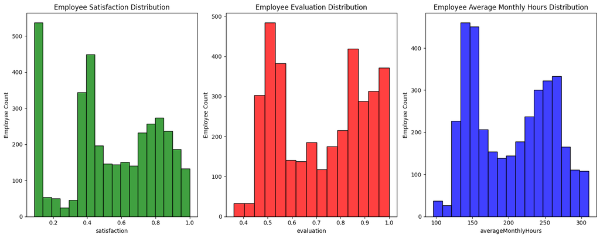

```python
# Import necessary libraries
import matplotlib.pyplot as plt
import seaborn as sns

# Set up the matplotlib figure
f, axes = plt.subplots(ncols=3, figsize=(15, 6))

# Graph Employee Satisfaction
sns.histplot(df.satisfaction, kde=False, color="g", ax=axes[0]).set_title('Employee Satisfaction Distribution')
axes[0].set_ylabel('Employee Count')

# Graph Employee Evaluation
sns.histplot(df.evaluation, kde=False, color="r", ax=axes[1]).set_title('Employee Evaluation Distribution')
axes[1].set_ylabel('Employee Count')

# Graph Employee Average Monthly Hours
sns.histplot(df.averageMonthlyHours, kde=False, color="b", ax=axes[2]).set_title('Employee Average Monthly Hours Distribution')
axes[2].set_ylabel('Employee Count')

# Display the plots
plt.tight_layout()
plt.show()
```

**Explanation of the Graphs**

1. **Employee Satisfaction Distribution:** a. Displays the distribution of employees' satisfaction scores. b. Scores range from 0 to 1, with peaks at low satisfaction values (~0.1) and moderate to high satisfaction values (~0.4 and 0.8). c. Indicates that a significant number of employees have very low or moderately high satisfaction. d. Many employees have low satisfaction, which could be a concern for employee retention.
2. **Employee Evaluation Distribution:** a. Shows the distribution of performance evaluation scores. b. Evaluations range from 0.4 to 1, with peaks at lower evaluations (~0.5) and high evaluations (~0.9). c. Suggests a bimodal distribution, where many employees either perform at a high level or a relatively lower level, with fewer in the middle.
3. **Employee Average Monthly Hours Distribution:** a. Illustrates the distribution of employees' average monthly hours worked. b. Values range between 100 and 300 hours, with peaks around 150 hours and 250 hours. c. Indicates that most employees either work close to standard hours or significantly longer.

**Potential areas of improvement**

**Satisfaction:** Addressing the needs of low-satisfaction employees can improve morale and reduce turnover. High satisfaction employees should be encouraged and supported to maintain engagement.

**Evaluation:** The company could focus on improving the performance of the lower-performing group through training or motivation. High performers may require recognition to sustain their productivity.

**Work Hours:** The distribution suggests the possibility of overwork for a significant subset of employees. Balancing workloads could improve overall satisfaction and reduce burnout risks.

## 3d. Salary V.S. Turnover

**Summary:** This is not unusual. Here's what I found:

- Majority of employees who left either had **low** or **medium** salary.
- Barely any employees left with **high** salary
- Employees with low to average salaries tend to leave the company.

**Stop and Think:**

- What is the work environment like for low, medium, and high salaries?
- What made employees with high salaries to leave?

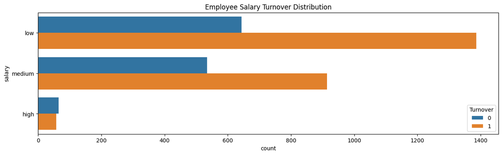

```python
f, ax = plt.subplots(figsize=(15, 4))
sns.countplot(y="salary", hue='Turnover', data=df).set_title('Employee Salary Turnover Distribution');
```

[figure not shown]

## 3e. Department V.S. Turnover

**Summary:** Let's see more information about the departments. Here's what I found:

- The **sales, technical, and support department** were the top 3 departments to have employee turnover
- The management department had the smallest amount of turnover

**Stop and Think:**

- If we had more information on each department, can we pinpoint a more direct cause for employee turnover?

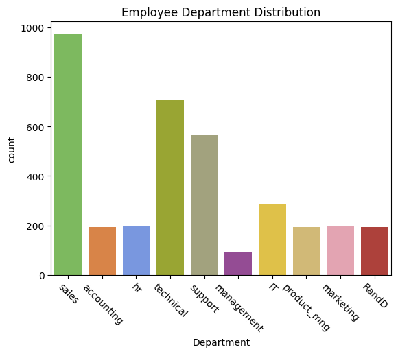

```python
# Import necessary libraries
import matplotlib.pyplot as plt
import seaborn as sns

# Ensure 'Department' exists in the DataFrame and has no null values
if 'Department' in df.columns:
    if df['Department'].isnull().any():
        df = df.dropna(subset=['Department'])

    # Define the color palette (match the number of unique values in 'Department')
    unique_departments = df['Department'].nunique()
    color_types = ['#78C850', '#F08030', '#6890F0', '#A8B820', '#A8A878',
                   '#A040A0', '#F8D030', '#E0C068', '#EE99AC', '#C03028'][:unique_departments]

    # Create the count plot and set 'Department' as the hue variable
    sns.countplot(x='Department', data=df, hue='Department', palette=color_types, legend=False).set_title('Employee Department Distribution')

    # Rotate x-axis labels for better readability
    plt.xticks(rotation=-45)

    # Display the plot
    plt.show()
else:
    print("Error: 'Department' column is not present in the DataFrame.")
```

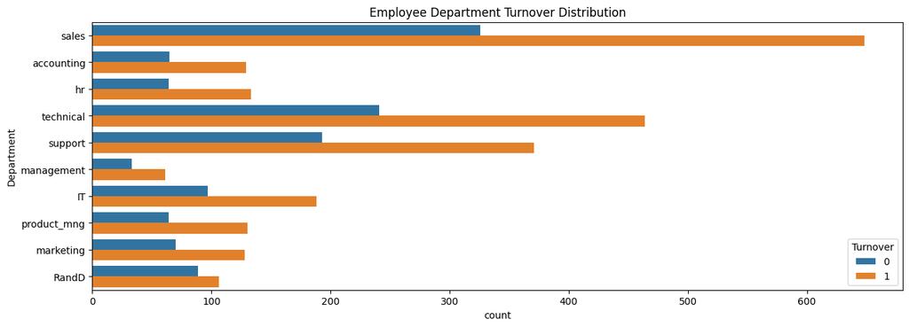

```python
f, ax = plt.subplots(figsize=(15, 5))
sns.countplot(y="Department", hue='Turnover', data=df).set_title('Employee Department Turnover Distribution');
```

## 3f. Turnover V.S. ProjectCount

**Stop and Think:**

- Why are employees leaving at the lower/higher spectrum of project counts?
- Does this means that employees with project counts 2 or less are not worked hard enough or are not highly valued, thus leaving the company?
- Do employees with 6+ projects are getting overworked, thus leaving the company?

```
[Text(0, 0.5, 'Percent')]
```

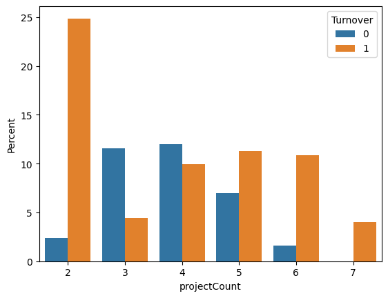

```python
ax = sns.barplot(x="projectCount", y="projectCount", hue="Turnover", data=df, estimator=lambda x: len(x) / len(df) * 100)
ax.set(ylabel="Percent")
```

## 3g. Turnover V.S. Evaluation

**Summary:**

- There is a biomodal distribution for those that had a turnover.
- Employees with **low** performance tend to leave the company more
- Employees with **high** performance tend to leave the company more
- The **sweet spot** for employees that stayed is within **0.6-0.8** evaluation

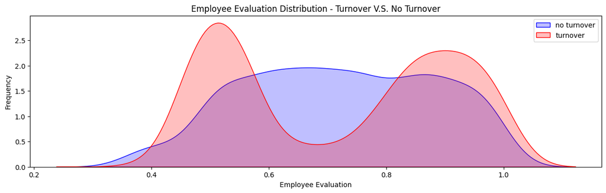

```python
# Kernel Density Plot
import matplotlib.pyplot as plt
import seaborn as sns

# Set up the figure size
fig = plt.figure(figsize=(15, 4))

# Plot KDE for no turnover
ax = sns.kdeplot(
    df.loc[(df['Turnover'] == 0), 'evaluation'],
    color='b',
    fill=True,  # Updated from `shade=True` to `fill=True`
    label='no turnover'
)

# Plot KDE for turnover
ax = sns.kdeplot(
    df.loc[(df['Turnover'] == 1), 'evaluation'],
    color='r',
    fill=True,  # Updated from `shade=True` to `fill=True`
    label='turnover'
)

# Set axis labels and title
ax.set(xlabel='Employee Evaluation', ylabel='Frequency')
plt.title('Employee Evaluation Distribution - Turnover V.S. No Turnover')

# Display the legend and plot
plt.legend()
plt.show()
```

## 3h. Turnover V.S. AverageMonthlyHours

**Summary:**

- Another bi-modal distribution for employees that turnovered
- Employees who had less hours of work **(~150hours or less)** left the company more
- Employees who had too many hours of work **(~250 or more)** left the company
- Employees who left generally were **underworked** or **overworked**.

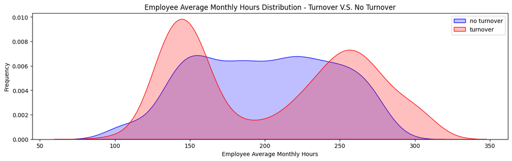

```python
# KDEPlot: Kernel Density Estimate Plot
import matplotlib.pyplot as plt
import seaborn as sns

# Set up the figure size
fig = plt.figure(figsize=(15, 4))

# Plot KDE for no turnover
ax = sns.kdeplot(
    df.loc[(df['Turnover'] == 0), 'averageMonthlyHours'],
    color='b',
    fill=True,  # Updated from `shade=True` to `fill=True`
    label='no turnover'
)

# Plot KDE for turnover
ax = sns.kdeplot(
    df.loc[(df['Turnover'] == 1), 'averageMonthlyHours'],
    color='r',
    fill=True,  # Updated from `shade=True` to `fill=True`
    label='turnover'
)

# Set axis labels and title
ax.set(xlabel='Employee Average Monthly Hours', ylabel='Frequency')
plt.title('Employee Average Monthly Hours Distribution - Turnover V.S. No Turnover')

# Display the legend and plot
plt.legend()
plt.show()
```

## 3i. Turnover V.S. Satisfaction

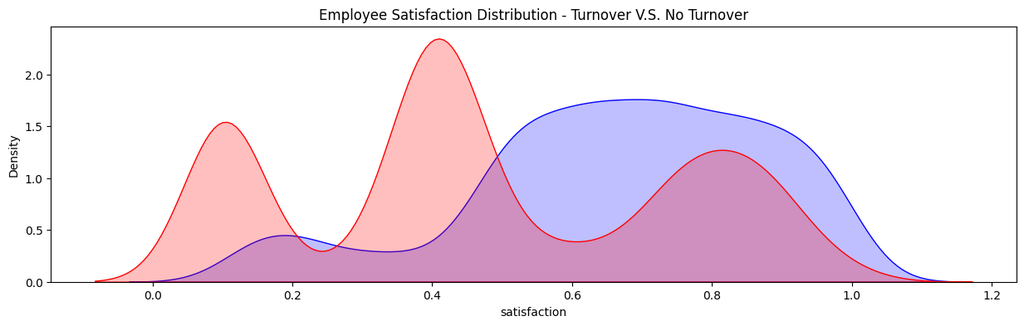

```python
# KDEPlot: Kernel Density Estimate Plot
fig = plt.figure(figsize=(15,4))
ax = sns.kdeplot(df.loc[(df['Turnover'] == 0), 'satisfaction'], color='b', fill=True, label='no turnover')
ax = sns.kdeplot(df.loc[(df['Turnover'] == 1), 'satisfaction'], color='r', fill=True, label='turnover')
plt.title('Employee Satisfaction Distribution - Turnover V.S. No Turnover')
```

## 3j. ProjectCount VS AverageMonthlyHours

**Summary:**

- As project count increased, so did average monthly hours
- Something weird about the boxplot graph is the difference in averageMonthlyHours between people who had a turnver and did not.
- Looks like employees who **did not** have a turnover had **consistent** averageMonthlyHours, despite the increase in projects
- In contrast, employees who **did** have a turnover had an increase in averageMonthlyHours with the increase in projects

**Stop and Think:**

- What could be the meaning for this?
- **Why is it that employees who left worked more hours than employees who didn't, even with the same project count?**

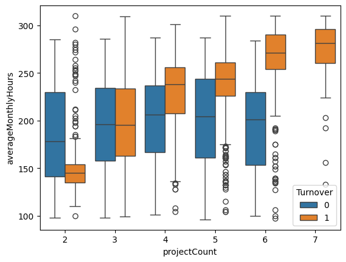

```python
#ProjectCount VS AverageMonthlyHours [BOXPLOT]
#Looks like the average employees who stayed worked about 200hours/month. Those that had a turnover worked about 250hours/month and 150hours/month

import seaborn as sns
sns.boxplot(x="projectCount", y="averageMonthlyHours", hue="Turnover", data=df)
```

## 3k. ProjectCount VS Evaluation

**Summary:** This graph looks very similar to the graph above. What I find strange with this graph is with the turnover group. There is an increase in evaluation for employees who did more projects within the turnover group. But, again for the non-turnover group, employees here had a consistent evaluation score despite the increase in project counts.

**Questions to think about:**

- **Why is it that employees who left, had on average, a higher evaluation than employees who did not leave, even with an increase in project count? **
- Shouldn't employees with lower evaluations tend to leave the company more?

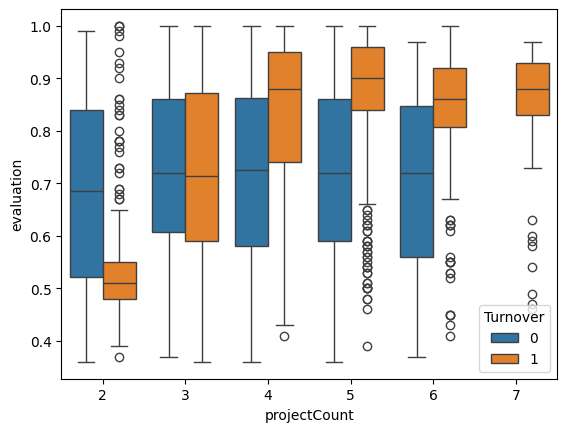

```python
#ProjectCount VS Evaluation
#Looks like employees who did not leave the company had an average evaluation of around 70% even with different projectCounts
#There is a huge skew in employees who had a turnover though. It drastically changes after 3 projectCounts.
#Employees that had two projects and a horrible evaluation left. Employees with more than 3 projects and super high evaluations left
import seaborn as sns
sns.boxplot(x="projectCount", y="evaluation", hue="Turnover", data=df)
```

## 3l. Satisfaction VS Evaluation

**Summary:** This is by far the most compelling graph. This is what I found:

- There are **3** distinct clusters for employees who left the company

**Cluster 1 (Hard-working and Sad Employee):** Satisfaction was below 0.2 and evaluations were greater than 0.75. Which could be a good indication that employees who left the company were good workers but felt horrible at their job.

- **Question:** What could be the reason for feeling so horrible when you are highly evaluated? Could it be working too hard? Could this cluster mean employees who are "overworked"?

**Cluster 2 (Bad and Sad Employee):** Satisfaction between about 0.35~0.45 and evaluations below ~0.58. This could be seen as employees who were badly evaluated and felt bad at work.

- **Question:** Could this cluster mean employees who "under-performed"?

**Cluster 3 (Hard-working and Happy Employee):** Satisfaction between 0.7~1.0 and evaluations were greater than 0.8. Which could mean that employees in this cluster were "ideal". They loved their work and were evaluated highly for their performance.

- **Question:** Could this cluser mean that employees left because they found another job opportunity?

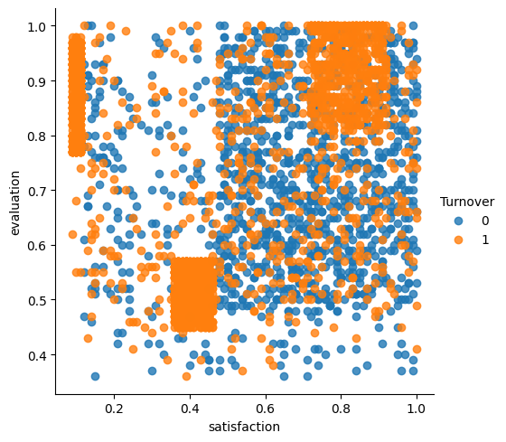

```python
sns.lmplot(x='satisfaction', y='evaluation', data=df,
           fit_reg=False, # No regression line
           hue='Turnover')   # Color by evolution stage
```

## 3m. Turnover V.S. YearsAtCompany

**Summary:** Let's see if theres a point where employees start leaving the company. Here's what I found:

- More than half of the employees with **4 and 5** years left the company
- Employees with **5** years should **highly** be looked into

**Stop and Think:**

- Why are employees leaving mostly at the **3-5** year range?
- Who are these employees that left?
- Are these employees part-time or contractors?

```
[Text(0, 0.5, 'Percent')]
```

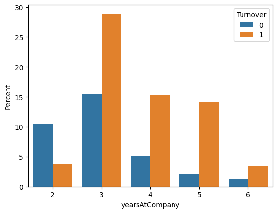

```python
ax = sns.barplot(x="yearsAtCompany", y="yearsAtCompany", hue="Turnover", data=df, estimator=lambda x: len(x) / len(df) * 100)
ax.set(ylabel="Percent")
```

# Decision Tree Model

**Summary:**

By using a decision tree model, it could rank the features used for the prediction. The top three features were employee satisfaction, yearsAtCompany, and evaluation. This is helpful in creating the model for logistic regression because it’ll be more interpretable to understand what goes into the model when we utilize less features.

**Top 3 Features:**

1. Satisfaction
2. YearsAtCompany
3. Evaluation

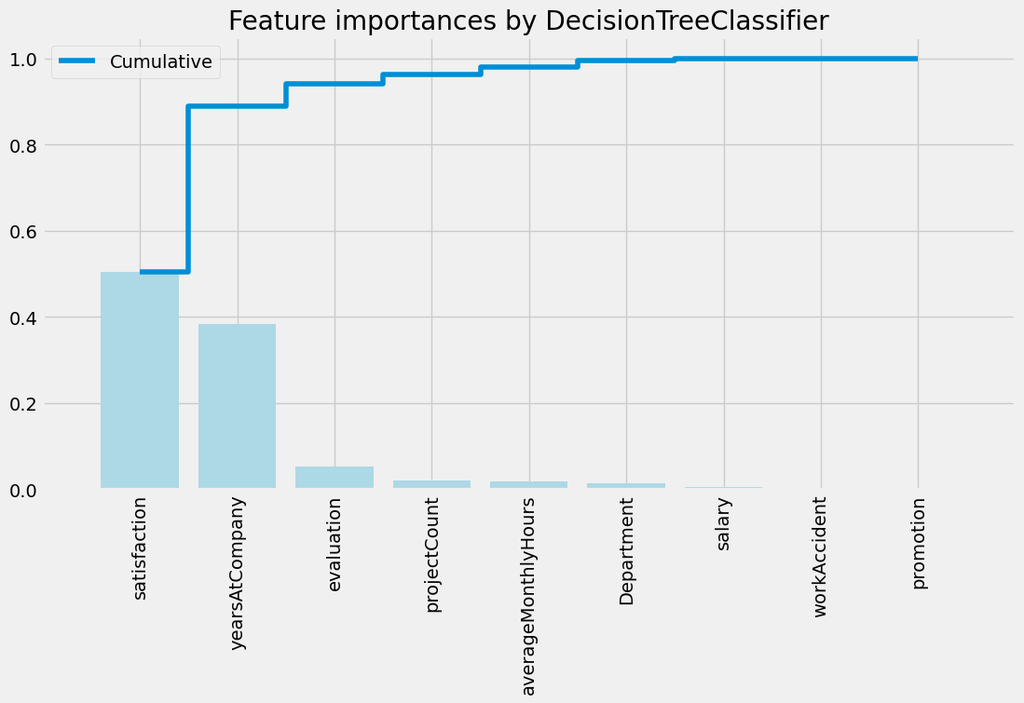

```python
from sklearn import tree
from sklearn.tree import DecisionTreeClassifier
from sklearn.model_selection import train_test_split
import matplotlib.pyplot as plt
import numpy as np
import pandas as pd

plt.style.use('fivethirtyeight')
plt.rcParams['figure.figsize'] = (12, 6)

# Load dataset
file_path = r"C:\Users\Sheetal\Dropbox\PC\Desktop\SGH Notes\Data Mining\turnover.csv"
df = pd.read_csv(file_path)

# Renaming certain columns for better readability
df = df.rename(columns={
    'satisfaction_level': 'satisfaction',
    'last_evaluation': 'evaluation',
    'number_project': 'projectCount',
    'average_montly_hours': 'averageMonthlyHours',
    'time_spend_company': 'yearsAtCompany',
    'Work_accident': 'workAccident',
    'promotion_last_5years': 'promotion',
})

# Filter the relevant columns
selected_columns = ['satisfaction', 'yearsAtCompany', 'evaluation', 'averageMonthlyHours', 'projectCount', 'Department', 'salary', 'promotion', 'workAccident', 'Turnover']
df = df[selected_columns]

# Convert categorical columns into numeric values
df["Department"] = df["Department"].astype('category').cat.codes
df["salary"] = df["salary"].astype('category').cat.codes

# Create train and test splits
target_name = 'Turnover'
X = df.drop('Turnover', axis=1)
y = df[target_name]

X_train, X_test, y_train, y_test = train_test_split(X, y, test_size=0.15, random_state=123, stratify=y)

# Create and fit the decision tree
dtree = DecisionTreeClassifier(
    class_weight="balanced",
    min_weight_fraction_leaf=0.01
)
dtree = dtree.fit(X_train, y_train)

# Plot the feature importances
importances = dtree.feature_importances_
feat_names = X.columns

indices = np.argsort(importances)[::-1]
plt.figure(figsize=(12, 6))
plt.title("Feature importances by DecisionTreeClassifier")
plt.bar(range(len(indices)), importances[indices], color='lightblue', align="center")
plt.step(range(len(indices)), np.cumsum(importances[indices]), where='mid', label='Cumulative')
plt.xticks(range(len(indices)), feat_names[indices], rotation='vertical', fontsize=14)
plt.xlim([-1, len(indices)])
plt.legend()
plt.show()
```